# Travail V1

Patricia Côté, Samy Gallienne, Élodie Gravel, Pascale Laveault-Allard

Dans ce travail, nous proposons un modèle de simulation de l’offre de travail au Québec calibré avec les données du Enquête sur la population active (EPA) pour la province de Québec. Nous utilisons ensuite ce modèle pour simuler l’effet de différentes réformes de la fiscalité québécoise sur l’offre de travail, le revenu des individus et la dispersion des revenus. Les trois réformes étudiées sont : 1. L’instauration d’un revenu minimum garanti 2. La mise en place d’une prime à l’emploi 3. Une combinaison des deux réformes

Comme mentionné, les effets de ces réformes seront comparés sur la base de l’offre de travail, de la distribution des revenus dans la société et, si le temps et les données nous le permettent, l’effet en bref sur les finances publiques.

# 0. Chargement des librairies

```r
library(readr) # package pour lire les .csv
library(compiler) # package pour le Just-in-time compilation
enableJIT(3) # Option du package compiler
```

```
## [1] 3
```

```r
set.seed(123) # Pour repliquer les resultats
```

# 1. Modèle d’offre de travail

## Préférences de l’individu

Nous supposons que les préférences des individus sont représentées par une fonction d’utilité de type log-log. La spécification des préférences de ce modèle est tirée d’une étude de Clavet, Duclos et Lacroix (https://www.utpjournals.press/doi/abs/10.3138/CPP.39.4.491) et adaptée en fonction des données disponibles:

$$U(C_i,L_i) = \alpha_{1i}\ln(\bar{L}-L_i) +\alpha_2\ln(\bar{L}-L_i)^2+ \alpha_3\ln(C_i)+\alpha_4\ln(C_i)^2 + \gamma_0(L_i=0) + \gamma_f(L_i\in[1750,2000])$$

Où $C_i$ le niveau de consommation (le revenu disponible), $L_i$ est la quantité de travail (annuelle, en heures) et $\bar{L}$ est le nombre maximal d’heures qu’un individu peut travailler annuellement. Ainsi spécifié, le terme $\bar{L}-L_i$ est le nombre d’heures annuelles de loisir consommé par l’individu *i*.

Le coefficient $\gamma_0$ permet d’inclure des coûts fixes au travail alors que le coefficient $\gamma_f$ permet de mettre une rigidité au travail à temps plein, défini entre 35 et 40 heures par semaine.

Toujours en s’inspirant de la proposition de Clavet, Duclos et Lacroix , l’hétérogénéité des préférences pour le loisir $\bar{L}-L$ est réflété dans le paramètre $\alpha_{1i}$:
$$\alpha_{1i} =\beta_0 + \beta_1\ln(age) + \beta_2\ln(age)^2 + \beta_3(prescolaire>0) + \beta_4~sexe + \beta_5~educ$$

Où *prescolaire>0* est une variable indicatrice égale à 1 si l’individu a au moins un enfant d’âge préscolaire à sa charge, *sexe* est une indicatrice égale à 1 si l’individu est une femme et *educ* réflète le niveau d’éducation.

Pour coder la fonction d’utilité, la vecteur de coefficients est noté $\theta = (\alpha_2, \alpha_3, \alpha_4, \gamma_0, \gamma_f)$ et le coefficient $\alpha_{1i}$ est codé dans une fonction séparée *alpha1*, qui elle dépend d’un vecteur de coefficients $\beta=(\beta_0, \beta_1, \beta_2, \beta_3, \beta_4, \beta_5)$.

```r
Utilite <- function(i,L,beta,theta){
# Fonction d'utilité du travail et de la consommation
      util <- alpha1(i,beta)*log(Lmax-L)+ theta[1]*log((Lmax-L)^2)+  theta[2]*log(Y(i,L)) + theta[3]*log((Y(i,L))^2)+ theta[4]*as.numeric(L==0) + theta[5]*as.numeric((L>=1750 & L<=2000))
  return(util)
}

alpha1 <- function(i, beta){
    alpha1 <- beta[1]+ beta[2]*log(age[i])+ beta[3]*log((age[i])^2)+ beta[4]*prescolaire[i]+ beta[5]*sexe[i] + beta[5]*educ[i]
  return(alpha1)
}
```

L’utilité est donnée par une fonction qui prend comme argument l’individu *i*, le nombre d’heures travaillées *L* et le vecteur de coefficients individuels *beta* et le vecteur de paramètres *theta*. *Lmax* est le nombre d’heures travaillées maximales $\bar{L}$.

## Contrainte budgétaire

La consommation (ou revenu disponible) est donnée par la contrainte budgétaire qui dépend du salaire horaire de l’individu $w_i$, de ses heures travailles $L_i$ et de la fonction de taxation $t(\cdot)$:

$$w_iL_i-t(w_iL_i)\geq C_i$$

qui sera saturée à l’optimum. La fonction de taxation $t(w_iL_i)$ est une fonction non-linéaire du revenu de travail brut. $w_i$ est le salaire horaire pour chaque individu *i*. Le code R associé à au revenut disponible, assumant que la contrainte budgétaire est serrée, est donné par:

```r
Y <- function(i,L){
  # Calcule la consommation nette (revenu disponible)
  dispo <- L*wage[i]-itax(L*wage[i])[1]
  return(dispo)
}
```

La consommation est une fonction de l’individu *i* (son salaire) et du nombre d’heures travaillées *L*. Elle dépend aussi de la taxation du revenu par la fonction *taxe*, qui sera définie à la section 3 sur les règles fiscales qubécoises et canadiennes.

## Maximisation sous contrainte

Pour maximiser l’utilité de l’individu, on peut substituer la contrainte budgétaire dans la fonction objectif:

$$U(L_i) = \alpha_{1i}\ln(\bar{L}-L) +\alpha_2\ln(\bar{L}-L)^2+ \alpha_3\ln(w_iL_i-t(w_iL_i))+\alpha_4\ln(w_iL_i-t(w_iL_i))^2 + \gamma_0(L=0) + \gamma_f(L\in[1750,2000])$$

En supposant que *L* est une variable continue, que $t(\cdot)$ est différentiable, et que $\gamma_0=\gamma_f=0$, on peut prendre les conditions de premier ordre et réécrire le taux maginal de substitution entre le loisir $\bar{L}-L$ et la consommation $Y_i$:

$$\frac{\bar{L}-L_i}{C_i}=\frac{\bar{L}-L_i}{w_iL_i-t(w_iL_i)}=\frac{\alpha_{1i}+2\alpha_2}{(\alpha_3+2\alpha_4)~w_i(1-t'(w_iL_i))}$$

On voit donc que le $\alpha_{1i}$ permet à deux individus ayant le même salaire horaire $w_i$ d’avoir des taux marginaux de substitution entre le loisir et la consommation différents en fonctions de caractéristiques de ces individus.

Cependant, nous supposons ici un modèle d’offre de travail à choix discrets, comme dans l’étude de Clavet, Duclos et Lacroix. En effet, les individus en réalité ne peuvent ajuster leurs heures de travail que de façon discrète (des heures entières). Puisque ce sont des heures annuelles, ce n’est pas une hypothèse très forte. La fonction suivante évalue l’utilité pour différents choix d’heure de travail:

```r
umarginal <- function(i,incr,beta,theta){
# calcule l'utilite marginale de l'individu i par increments de incr heures de travail
  lsup <- seq(0,Lmax,by=incr) # vecteur des heures travaillees
  util <- sapply(lsup,function(x) Utilite(i,x,beta,theta)) # evalue l'utilite pour chaque niveau d'heures travaillees
  util2 <- c(util[2:(length(util))],0) # decale le vecteur des utilites
  deltautil <- util2-util # utilite marginale
  return(list(lsup[1:length(lsup)-1],deltautil[1:length(lsup)-1],util[1:length(lsup)-1]))
}
```

La fonction prend comme arguments l’individu *i*, la variation discrète annuelle des heures qu’il est possible de travailler *incr*, que le vecteur de préférences individuelles *beta* et le vecteur de paramètre de la fonction d’utilité *theta*. La fonction retourne une liste de trois éléments. Premièrement, *lsup*, le vecteur des heures travaillées auxquelles la fonction est évaluée. Deuxièmement, *deltautil* est l’utilité marginale entre $L$ et $L+1$ heures travaillées. Troisièmement, *util* est l’utilité évaluée à chaque valeur de *lsup*. Le nombres d’heures optimales travaillées *Loptimal* est simplement la valeur de *L* qui est associée à la plus grande utilité:

```r
Loptimal <- function(lsup, util){
  position <- which(util==max(util)) #utilite maximale
  return(lsup[position])
}
```

Voici un jeu de données fictives (10 observations) sur lesquelles nous avons testé les fonctions (sans taxes ni transferts)

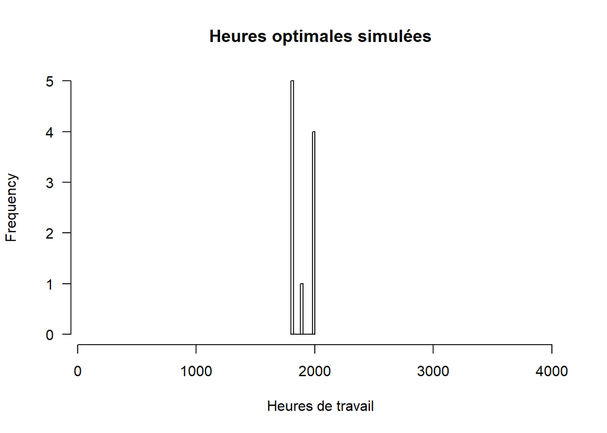

```r
#Fonction de taxation temporaire: aucune taxe
itax<- function(inc){
  return(0)
}

#Vecteurs de coefficients arbitraires
Lmax=4000
beta <- c(1, -1, 1, 1, -1, 1)
theta <- c(1, 1, 1, 1, 1)

#Données aléatoires
#Enlever le seed pour voir plusieurs tirages et le graphique s'adapter
wage      <-   sample(12:150, 10, replace = TRUE)
age      <-    sample(20:80, 10, replace = TRUE)
prescolaire <- sample(0:1, 10, replace = TRUE)
sexe  <-       sample(0:1, 10, replace = TRUE)
educ <-        sample(0:6, 10, replace = TRUE)

#Nombre d'individus
n<-10
Lopt<- rep(0, n)

for (i in 1:n) {
  umarg <- umarginal(i,100, beta, theta)
  lsup<- unlist(umarg[1])
  util <-unlist(umarg[3] )
  Lopt[i] <- Loptimal(lsup, util)
}

hist(Lopt,
     main="Heures optimales simulées",
     xlab="Heures de travail",
     xlim=c(100,4000),
     las=1,
     breaks=10)
```

Dans cet exemple, les individus ne peuvent pas travailler 0 heures même si la fonction d’utilité est bonifiée quand *L=0* car *ln(0)* n’est pas défini. Les heures simulées dépendent fortement des paramères arbitraires postulés. Dans ce cas hypothétique, nous avons posé que tous les intrants de la fonction d’utilité ont un effet égal à un, sauf l’âge et le fait d’être une femme qui diminuent la préférence pour le loisir. La modification de ces coefficients affecte la distribution des heures de travail simulée dans cette cohorte.

# 2. Données de l’Enquête sur la population active

Pour cette analyse, nous allons utiliser les données de l’EPA pour la province de Québec (*PROV=24*). Afin de ne pas inclure les effets exogènes sur l’économie dus au COVID-19, nous avons téléchargé les données de février 2020. - La commande *complete.case* enlève les valeurs manquantes - *n* est le nombre d’individus - *wage* est le salaire horaire habituel déclaré pour chaque individu - *Xmat* est la matrice des characteristiques individuelles - *theta* est un vecteur de paramètres à estimer - *alpha* est le vecteur (impliqué par *theta*) des préférences individuelles.

## Chargement des données

Pour mettre en forme les données, nous avons utilisé la commande *complete.cases* pour enlever les valeurs manquantes. Nous avons également noté *n* le nombre d’individus.

```r
lfs <- read_csv("./LFS-71M0001-E-2020-February_F1.csv", col_types = cols()) # importe les données du LFS, May 2018
#lfs <- ds
lfsqc <- lfs[lfs$PROV==24,] # garde uniquement le Québec
rm(lfs) # supprime la base initiale de la mémoire
lfsqc <- lfsqc[,c("AGE_12","SEX","EDUC","ATOTHRS","HRLYEARN","EFAMTYPE","SCHOOLN","AGYOWNK","FINALWT")] # garde seulement certaines variables
n0 <- nrow(lfsqc) # garde le nombre d'observations initiales
missingweight <- c(lfsqc[!complete.cases(lfsqc),"FINALWT"])[[1]] #garde les poids des individus qui seront enlevés
lfsqc <- lfsqc[complete.cases(lfsqc), ] # enlève les observations avec des variables manquantes
lfsqc <- lfsqc[sample(1:nrow(lfsqc), 1000, replace=FALSE),] # sous-échantillonage pour les tests (à commenter pour l'analyse finale)
n <- nrow(lfsqc) # nombre d'individus dans la base
wage <- as.numeric(lfsqc$HRLYEARN) # salaire horaire
prescolaire <- ifelse(lfsqc$AGYOWNK == 1, 1, 0) # enfant le plus jeune à moins de 6 ans: 1= oui, 2=non
menage <- ifelse(lfsqc$EFAMTYPE == 18, "autre", ifelse(lfsqc$EFAMTYPE > 13 & lfsqc$EFAMTYPE < 18, "monoparental",
  ifelse(lfsqc$EFAMTYPE > 1 & lfsqc$EFAMTYPE < 14, "couple", ifelse(lfsqc$EFAMTYPE == 1, 1, lfsqc$EFAMTYPE))))
# classification du type de ménage
enfant <- ifelse(lfsqc$EFAMTYPE == 3 | lfsqc$EFAMTYPE == 6 | lfsqc$EFAMTYPE == 9 | lfsqc$EFAMTYPE == 12 |
  lfsqc$EFAMTYPE == 14 | lfsqc$EFAMTYPE == 16, 1, 0) # 1 = ménage avec enfant = 1, sans enfant = 0
Xmat <- matrix(c(lfsqc$AGE_12,lfsqc$SEX,lfsqc$EDUC),n,3) # matrice des variables explicatives
Xmat <- matrix(c(rep(1,n),Xmat),n,4) # ajoute une constante
k <- 4 # nombre de variables explicatives (incluant la constante)
Xmat[,3] <- as.numeric(Xmat[,3]==2) # recode la variable "sex": 1=femme, 0=homme
corfact <- sum(lfsqc$FINALWT)/(sum(lfsqc$FINALWT)+sum(missingweight))
wght <- as.numeric(lfsqc$FINALWT)/corfact # calcule les poids approximatifs (les val. manquantes sont parfaitement aléatoires)

summary(cbind(Xmat,wage)) # résumé des variables
```

```
##        V1          V2               V3              V4             wage
##  Min.   :1   Min.   : 1.000   Min.   :0.000   Min.   :0.000   Min.   : 5.13
##  1st Qu.:1   1st Qu.: 5.000   1st Qu.:0.000   1st Qu.:4.000   1st Qu.:21.23
##  Median :1   Median : 6.000   Median :1.000   Median :4.000   Median :28.73
##  Mean   :1   Mean   : 5.868   Mean   :0.535   Mean   :4.015   Mean   :31.36
##  3rd Qu.:1   3rd Qu.: 7.000   3rd Qu.:1.000   3rd Qu.:5.000   3rd Qu.:39.44
##  Max.   :1   Max.   :10.000   Max.   :1.000   Max.   :6.000   Max.   :92.31
```

## Statistiques descriptives

# 3. Règles fiscales québécoises

## Palliers d’imposition provinciaux et fédéraux

Nous allons aussi utiliser les taux de taxe et paliers suivants:

```r
  # source1: http://www.nrgcpa.ca/deductions-a-la-source-et-charges-sociales
  # source2: http://www4.gouv.qc.ca/FR/Portail/Citoyens/Evenements/immigrer-au-quebec/Pages/programme-aide-sociale.aspx

  # taux de taxe QC
  pp1 <- 0.15
  pp2 <- 0.2
  pp3 <- 0.24
  pp4 <- 0.2575

  # seuils de taxation QC
  p1 <- 15532
  p2 <- 44545
  p3 <- 89080
  p4 <- 108390

  # taux de taxe CAN
  pt1 <- 0.15
  pt2 <- 0.2050
  pt3 <- 0.26
  pt4 <- 0.29
  pt5 <- 0.33

  # seuils de taxation CAN
  f1 <- 12298
  f2 <- 48535
  f3 <- 97069
  f4 <- 150473
  f5 <- 214368

  as <- 1 # =1 programme aide sociale, =0 si enlève aide sociale
```

## Transferts

```r
transferts <- function(inc){
  #Crédit TPS-TVH - a completer, je voulais juste voir si la fonction fonctionnait bien :)
  ctps<-0
  ctc<-0
  ctfm<-0
  ctce<-0

  #Prime au travail maximal
  if (2400<inc & inc<19456) ptps <- 914.11 else ptps <- 0
  if (3600<inc & inc<30217) ptc <- 1426.90 else ptc <- 0
  if (2400<inc & inc<35680) ptfm <- 2539.2 else ptfm <- 0
  if (3600<inc & inc<49044) ptce <- 3303 else ptce <- 0
  #total PT
  PrimeTravail<-ptps+ptc+ptfm+ptce

  #Allocation canadienne pour les trvailleurs
  if (inc<23458) actps <- min(2280, ((inc-2400)*0.274)-((inc-12060)*0.20)) else actps <- 0
  if (inc<36308) actc <- min(3558, ((inc-3600)*0.274)-((inc-18520)*0.20)) else actc <- 0
  if (inc<18305) actfm <- min(1248, ((inc-2400)*0.15)-((inc-12065)*0.20)) else actfm <- 0
  if (inc<27629) actce <- min(1818, ((inc-3600)*0.14)-((inc-18540)*0.20)) else actce <- 0


  #Allocation canadienne pour enfants


  #Allocation famille


  #Crédit solidarité
  if(inc<35400) csps <- 718 else csps <- min(718,max(((inc-35400)*0.06)/12),ctps)
  if(inc<35400) csc <- 841 else csc <- min(841, max(((inc-35400)*0.06)/12),ctc)
  if(inc<35400) csfm <- 996 else csfm <- min(996, max(((inc-35400)*0.06)/12),ctfm)
  if(inc<35400) csce <-1119 else csce <- min(1119, max(((inc-35400)*0.06)/12),ctce)
  #total CS
  CreditSolidarite<-csps+csc+csfm+csce

  transferts <- PrimeTravail+ CreditSolidarite
  return(transferts)
}
```

## Calcul du revenu net

```r
itax <- function(inc){
  # Calcule les impôts sur le revenu

  if (inc<=f1){
    prv <- 0
    fed <- 0
  }
  if (inc>f1 & inc<=p1){
    prv <- 0
    fed <- pt1*(inc-f1)
  }
  if (inc>p1 & inc<=p2){
    prv <- pp1*(inc-p1)
    fed <- pt1*(inc-f1)
  }
  else if (inc>p2 & inc<=f2){
    prv <- pp1*(p2-p1) + pp2*(inc-p2)
    fed <- pt1*(inc-f1)
  }
  else if (inc>f2 & inc<=p3){
    prv <- pp1*(p2-p1) + pp2*(inc-p2)
    fed <- pt1*(f2-f1) + pt2*(inc-f2)
  }
  else if (inc>p3 & inc<=f3){
    prv <- pp1*(p2-p1) + pp2*(p3-p2) + pp3*(inc-p3)
    fed <- pt1*(f2-f1) + pt2*(inc-f2)
  }
  else if (inc>f3 & inc<=p4){
    prv <- pp1*(p2-p1) + pp2*(p3-p2) + pp3*(inc-p3)
    fed <- pt1*(f2-f1) + pt2*(f3-f2) + pt3*(inc-f3)
  }
  else if (inc>p4 & inc<=f4){
    prv <- pp1*(p2-p1) + pp2*(p3-p2) + pp3*(p4-p3) + pp4*(inc-p4)
    fed <- pt1*(f2-f1) + pt2*(f3-f2) + pt3*(inc-f3)
  }
  else if (inc>f4 & inc<=f5){
    prv <- pp1*(p2-p1) + pp2*(p3-p2) + pp3*(p4-p3) + pp4*(inc-p4)
    fed <- pt1*(f2-f1) + pt2*(f3-f2) + pt3*(f4-f3) + pt4*(inc-f4)
  }
  else if (inc>f5){
    prv <- pp1*(p2-p1) + pp2*(p3-p2) + pp3*(p4-p3) + pp4*(inc-p4)
    fed <- pt1*(f2-f1) + pt2*(f3-f2) + pt3*(f4-f3) + pt4*(f5-f4) + pt5*(inc-f5)
  }
  aemploi <- min(54200,inc)*0.012
  rrq <- 0 #max(min(58700,inc)-3500,0)*0.057
  rqap <- min(78500,inc)*0.00494

  asociale <- max(690*12 - max(inc-200*12,0),0)*as
  tax <-  prv + fed + aemploi + rrq + rqap - asociale -transferts(inc)
  return(c(tax,prv,fed,aemploi,rrq,rqap,asociale, transferts(inc)))
}
```

Cette fonction de taxe prend en compte les paliers d’imposition fédéraux (*fed*) et québécois (*prv*), ainsi que les contributions à l’assurance emploi (*aemploi*), au RQAP (*rqap*) et, finalement, le programme d’aide sociale (*asociale*). Notez que la contribution au RRQ (*rrq*) est commentée puique cela dépend de l’hypothèse faite sur la substituabilité intertemporelle des individus.

## Taux marginaux effectifs d’imposition

Notez qu’on peut directement voir l’impact de la fonction de taxe, sans hypothèses sur le comportement des individus en regardant les taux marginaux effectifs (TME) d’imposition. Le code suivant crée un graphique pour des incréments salariaux annuels de *incr* jusqu’à un revenu annuel de *imax* $

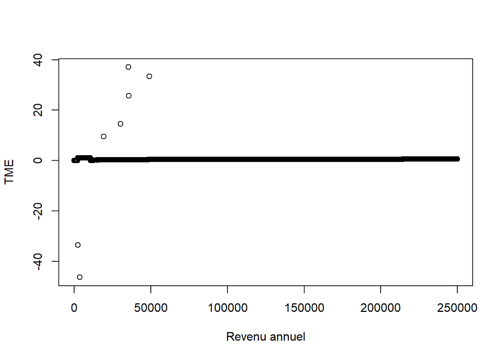

```r
tme <- function(incr,imax){
  # calcule les taux marginaux effectifs d'imposition, par incréments de "incr"$, jusqu'à imax$
  incm <- seq(0,imax,by=incr) # vecteur des niveaux de revenus
  tax <- sapply(incm,function(x) itax(x)[1]) # applique la taxe sur chaque niveau de revenu
  tax2 <- c(tax[2:(length(tax))],0) # décale le taux de taxe
  deltatax <- tax2-tax # taxe marginale
  tm <- deltatax/incr # taux marginal effectif
  plot(incm[1:length(incm)-1],tm[1:length(incm)-1],xlab='Revenu annuel', ylab='TME')
  return(list(incm[1:length(incm)-1],tm[1:length(incm)-1]))
}
outtme <- tme(100,250000)
```

# 4. Calibration

## Variables générales

Les variables globales sont définies comme suit: * *Lmax* est le nombre maximal d’heures qu’il est possible de travailler par année. Nous l’avons fixé à 4250 heures, soit 85 heures par semaine. * *weeks* est le nombre de semaines de travail par année, fixé à 50. * *lincr* est le nombre minimal d’heures annuelles de travail que l’individu peut ajuster. Nous l’avons fixé à 250 heures par année, soit des incréments de 5 heures par semaine.

```r
Lmax <- 4250
weeks <- 50
lincr <- 250
```

## Processus aléatoires

Pour calibrer le modèle d’offre de travail, nous allons utiliser les données sur les heures travaillées disponibles dans la *Labour Force Survey*. Comme il y a toujours une variabilité dans les données qui ne peut être captée par le modèle théorique, nous ajoutons des processus aléatoires au modèle spécifié plus haut. Pour ce faire, nous supposons des caractéristiques inobservables des individus qui rendent aléatoire la fonction de préférence pour le loisir:

Pour régler cette situation, nous allons utiliser les données sur les heures travaillées disponibles dans l’EPA.
$$\hat{\alpha_{1i}} = \alpha_{1i}+v$$
où *v* est un terme aléatoire normalement distribué (i.i.d) de moyenne zéro et variance $\sigma^2$.

Nous supposons aussi que la fonction d’utilité elle-même a un terme d’erreur $\xi_i$:

$$\hat{U}_i(C,L)=U_i(C,L)+\xi_i,$$

où $\xi_i$ est une loi d’extremum généralisée de type I (Loi de Gumbel). L’utilisation de cette règle de distribution est motivée dans l’article de Clavet, Duclos et Lacroix et repose sur la sur-représentation de valeurs extrèmes dans les données observées sur l’offre de travail.

## Méthode des moments généralisés simulés

Nous allons calibrer le modèle théorique avec les données du *LFS*. Essentiellement, il s’agit de trouver les valeurs de $\beta$ et de $\theta$ afin que les heures travaillées simulées par le modèle d’offre de travail basé sur la théorie économique soient le plus près possible des données observées dans le *LFS*. Pour ce faire, nous utilisons la méthode des moments généralisés, qui consiste à fixer certains paramètres de la distribution, comme la moyenne et l’écart-type et à sélectionner les valeurs de $\beta$ et de $\theta$ qui reproduisent ces *moments.*

Comme la population du sondage est diversifiée et que les caractéristiques individuelles influencent formement les préférences pour le loisir, il faut inclure plusieurs variables dans le modèle. Dans ce cas, il y a plusieurs combinaisons de $\beta$ et de $\theta$ qui permettent de répliquer la moyenne et l’écart-type des heures travaillées. On dit que le modèle est *sous-identifié*. Pour que le modèle soit identifié, il nous faut au minimum autant de moments que de paramètres à estimer. En multipliant le vecteur des heures travaillées par la matrice des caractéristiques individuelles, on obtient facilement des moments intuitifs.

Le code suivant génère les moments associés en prenant soin de pondérer les moyennes et l’écart-type, puisque es individus ne sont pas également représentatifs de la population.

```r
rhours <- as.numeric(lfsqc$ATOTHRS)*weeks # nombre d'heures annuelles sur une base de 'weeks' semaines de travail
wrhours <- rhours*wght
rwse <-  sqrt((sum(wght*(rhours^2))/sum(wght))-(sum(wrhours)/sum(wght))^2)
#rmoments <- c(colSums(matrix(rep(wrhours,k),n,k)*Xmat)/sum(wght),rwse,sum(as.numeric(rhours>=1750&rhours<=2000)*wght)/sum(wght),sum(as.numeric(rhours==0)*wght)/sum(wght)) # calcul des moments
rmoments <- c(colSums(matrix(rep(wrhours,k),n,k)*Xmat)/sum(wght),rwse,sum(as.numeric(rhours==2000)*wght)/sum(wght),sum(as.numeric(rhours==0)*wght)/sum(wght)) # calcul des moments
print(rmoments)
```

[output not shown]

On veut donc choisir une valeur de $\theta$ telle que les moments simulés par le modèle soient proche des moments dans les données. Malgré que nous ayons autant de moments que de paramètres, nous ne pouvons en général pas être certains qu’il existe une unique solution de $\theta$ . C’est pour cela que nous parlons habituellement de *calibration* et non d’*estimation* du modèle. En pratique, la calibration s’opère comme une estimation classique, i.e. nous allons minimiser la distance entre les moments simulés et les moments observés:

$$GMM(\theta)=(\mathbb{E}Moments(\theta)-Moments)'(\mathbb{E}Moments(\theta)-Moments)$$
où $\mathbb{E}Moments(\theta)$ est la moyenne des moments simulés pour différents tirages des $\varepsilon_i$ et $Moments$ sont les moments des données. La procédure est donc de minimiser $GMM(\theta)$. Voici le code R associé:

```r
wrapi <- function(i,sim,alpha,theta){
    u <- as.numeric(umarginal(i,lincr,alpha,theta)[[3]])+as.numeric(erreur[[sim]][i,])*exp(theta[k+1]) # utilité pour chaque niveau d'heures travaillées
      # notez ici le changement de variable "exp(theta[6])" afin de s'assurer que l'écart-type soit toujours un chiffre positif.
    h <- (which(u==max(u))-1)*lincr # heures travaillées qui maximisent l'utilité
    return(min(h))
}
simhours <- function(theta){
  alpha <- exp(as.numeric(Xmat%*%matrix(theta[1:k],k,1))) # simulation des préférences alpha pour chaque individu
  moments <- rep(0,length(theta)) # vecteur de zéros qui va contenir la moyenne des moments simulés
  for (sim in 1:nsim){
     hours <- as.numeric(sapply(1:n,function(i) wrapi(i,sim,alpha,theta)))
     wh <- wght*hours
     swse <-  sqrt((sum(wght*(hours^2))/sum(wght))-(sum(wh)/sum(wght))^2)
     #moments <- moments + c(colSums(matrix(rep(wh,k),n,k)*Xmat)/sum(wght),swse,sum(as.numeric(hours>=1750&hours<=2000)*wght)/sum(wght),sum(as.numeric(hours==0)*wght)/sum(wght)) # calcul des moments
    moments <- moments + c(colSums(matrix(rep(wh,k),n,k)*Xmat)/sum(wght),swse,sum(as.numeric(hours==2000)*wght)/sum(wght),sum(as.numeric(hours==0)*wght)/sum(wght)) # calcul des moments
  }
  moments <- moments/nsim # fait la moyenne
  return(moments)
}

distrhours <- function(theta){
  moments <- simhours(theta) # moments simulés
#  gmm <- sum((moments/max(rmoments,rep(1,length(theta)))-rep(1,length(theta)))^2) # distance entre les moments simulés et les moments dans les données
   gmm <- sum((moments-rmoments)^2) # distance entre les moments simulés et les moments dans les données
  return(gmm)
}
```

```r
summary(exp(as.numeric(Xmat%*%matrix(theta0[1:k],k,1))))
```

[output not shown]

Rappelez vous qu’un choc aléatoire est ajouté à $\alpha_i$ pour tenir compte de l’hétérogénéité inobservée. Une bonne pratique est de simuler les erreurs d’abord afin qu’elles soient les mêmes pour chaque évaluation des différentes valeurs de $\theta$ et ainsi éviter les problèmes numérique pour un nombre faible de simulations.

```r
####### Dernières variables globales #######
nsim <- 1
erreur <- vector("list", nsim)
erreur2 <- vector("list",nsim)
for (s in 1:nsim){
  erreur[[s]] <- matrix(rnorm(n*(Lmax/lincr)),n,(Lmax/lincr))
  erreur2[[s]] <- rnorm(n)
}
```

On peut donc maintenant lancer la calibration.

```r
thetatry <- c(0.01239040, -0.01531411,  0.01137535,  0.01061802,  0.01987626,  0.01161269, 0.01602443)
thetatry[4] <- thetatry[4]+0.01
thetatry[k+2] <- thetatry[k+2]+1
thetatry[k+3] <- thetatry[k+3]+0.7
#out <- optim(thetatry, fn=distrhours) # minimise la fonction gmmfct prenant theta comme valeur de départ.
#thetatry <- out$par
#print(out)
```

```r
print(thetatry)
print(simhours(thetatry))
print(rmoments)
```

[output not shown]

```r
hist(rhours)
print(max(rhours))
```

[output not shown]

```r
simwork <- function(theta,sim){
    hours <- rep(0,n) # vecteur de zéros qui va contenir les heures travaillées simulées
    alpha <- exp(as.numeric(Xmat%*%matrix(theta[1:k],k,1))) # simulation des préférences alpha pour chaque individu
    for (i in 1:n){
      u <- umarginal(i,lincr,alpha,theta)[[3]]+as.numeric(erreur[[sim]][i,])*exp(theta[k+1]) # utilité pour chaque niveau d'heures travaillées
      h <- (which(u==max(u))-1)*lincr # heures travaillées qui maximisent l'utilité
      hours[i] <- h # conserve dans le vecteur
    }
    return(hours)
}
hist(simwork(thetatry,1))
```

[output not shown]